# Parte 2

# Actividad 1

[Este paper](https://openreview.net/pdf?id=Bygq-H9eg) hace una comparación de distintas redes, desde AlexNet hasta VGG-16 y ResNet-50. A continuación se harán comentarios generales sobre ambas arquitecturas.

## VGG-16

### Características

Como alternativa a AlexNet, VGG-16 es el resultado del trabajo que se encuentra documentado en [este paper](http://arxiv.org/abs/1409.1556v6), junto con otras redes. Este trabajo es la exploración de distintas arquitecturas, donde la implementación de filtros convolucionales es de orden pequeño ($3\times3$), permitiendo distintas arquitecturas desde 16 (VGG-16) hasta 19 capas (VGG-19).

Las siguientes tablas indican las distintas arquitecturas probadas en el trabajo, donde la red estudiada en este trabajo corresponde a la **D**. La segunda tabla indica la cantidad de parámetros totales en millones.

[figure not shown]

### Resultados ImageNet

La red presentó, según [ésta página](http://www.robots.ox.ac.uk/~vgg/research/very_deep/), un error del 7.5% y 7.4% en fase de entrenamiento y test respectivamente sobre los datos de la competición de 2012. Estos resultados le permitieron a esta red ganar el primer lugar en la competición de ImageNet 2014

[figure not shown]

## ResNet-50

### Características

La principal característica de las redes residuales, es la de la incorporación de módulos residuales. Estos permiten establecer una relación entre la información de entrada y la de salida en cada capa, donde esta última se redefine como la suma neta entre ambas. Esto permite amortiguar el efecto de aquellas capas cuyos pesos son muy bajos o no aportan al problema, además de permitir arquitecturas de más capas, pero con menor complejidad que las redes VGG.

[figure not shown]

El paper que da origen a esta arquitectura puede revisarse [aquí](https://arxiv.org/abs/1512.03385). En este trabajo se establece una comparativa entre VGG-19 y dos redes equivalentes, *plain-network* y *residual-network*, ambas en un rango de 18 a 152 capas de profundidad, aunque con la diferencia de que la última implementa estas unidades residuales modulares entre capas.

[figure not shown]

Estas capas se mantienen de $3\times3$, y para arquitecturas de +50 capas se implementan unidades llamadas *bottleneck* que apuntan a mejorar la eficiencia de la red

[figure not shown]

Más comparaciones pueden verse en [esta presentación](http://cs231n.stanford.edu/slides/2017/cs231n_2017_lecture9.pdf).

### Resultados ImageNet

Los resultados de esta red dieron un error de 3.57% según los resultados de la [competencia para 2015](http://www.image-net.org/challenges/LSVRC/2015/results#clsloc), los que le dieron el primer lugar. Este resultado es incluso mejor que el 5% que alcanzan en promedio los humanos.

[figure not shown]

# Actividad 2

La ejecución de `test_vgg.py` da como resultado lo siguiente

```
# python3 test_vgg.py
La predicción tardó 1192.8822672367096 segundos
accuracy: 0.576833333333
[[930  38  15  57   8  22  41  14  14  26]
 [ 31 625  94  38  29  18  36  13  26   9]
 [ 31 106 320  34  67  27  28  32  25   9]
 [ 56  48  35 376  20  14  12  16  15   8]
 [ 11  45  95  18 290  43   7  18  22   4]
 [ 18  37  65  21  67 189   5  42  14  12]
 [ 54  37  46   6  20  11 251   7   6   8]
 [ 11  31  44  10  39  57   3 141  34  17]
 [ 10  68  30  28  31  22   9  36 130  12]
 [ 26  20  23  20  18  26  17  19  27 209]]

[[ 0.8   0.03  0.01  0.05  0.01  0.02  0.04  0.01  0.01  0.02]
 [ 0.03  0.68  0.1   0.04  0.03  0.02  0.04  0.01  0.03  0.01]
 [ 0.05  0.16  0.47  0.05  0.1   0.04  0.04  0.05  0.04  0.01]
 [ 0.09  0.08  0.06  0.63  0.03  0.02  0.02  0.03  0.02  0.01]
 [ 0.02  0.08  0.17  0.03  0.52  0.08  0.01  0.03  0.04  0.01]
 [ 0.04  0.08  0.14  0.04  0.14  0.4   0.01  0.09  0.03  0.03]
 [ 0.12  0.08  0.1   0.01  0.04  0.02  0.56  0.02  0.01  0.02]
 [ 0.03  0.08  0.11  0.03  0.1   0.15  0.01  0.36  0.09  0.04]
 [ 0.03  0.18  0.08  0.07  0.08  0.06  0.02  0.1   0.35  0.03]
 [ 0.06  0.05  0.06  0.05  0.04  0.06  0.04  0.05  0.07  0.52]]
```

Mientras que la salida de `test_resnet.py` regresa lo siguiente

```
grupo12_ml@kraken:~/redes$ python3 test_resnet.py
La predicción tardó 562.9957280158997 segundos
accuracy: 0.659
[[957  31  17  35  15  22  39  15  10  24]
 [ 24 674  90  36  18  13  25  14  20   5]
 [ 27  98 369  30  67  17  20  21  23   7]
 [ 60  54  28 395  10  16  18   4   8   7]
 [ 25  36  96  15 337  21  12   5   6   0]
 [ 19  20  44  12  34 265   7  40  16  13]
 [ 62  35  28  12   9   6 285   1   4   4]
 [ 17  15  28   8  20  56   3 208  27   5]
 [ 18  27  21  13  14  25   2  21 219  16]
 [ 21  13  14   4   3  49   3  21  32 245]]

[[ 0.82  0.03  0.01  0.03  0.01  0.02  0.03  0.01  0.01  0.02]
 [ 0.03  0.73  0.1   0.04  0.02  0.01  0.03  0.02  0.02  0.01]
 [ 0.04  0.14  0.54  0.04  0.1   0.03  0.03  0.03  0.03  0.01]
 [ 0.1   0.09  0.05  0.66  0.02  0.03  0.03  0.01  0.01  0.01]
 [ 0.05  0.07  0.17  0.03  0.61  0.04  0.02  0.01  0.01  0.  ]
 [ 0.04  0.04  0.09  0.03  0.07  0.56  0.01  0.09  0.03  0.03]
 [ 0.14  0.08  0.06  0.03  0.02  0.01  0.64  0.    0.01  0.01]
 [ 0.04  0.04  0.07  0.02  0.05  0.14  0.01  0.54  0.07  0.01]
 [ 0.05  0.07  0.06  0.03  0.04  0.07  0.01  0.06  0.58  0.04]
 [ 0.05  0.03  0.03  0.01  0.01  0.12  0.01  0.05  0.08  0.6 ]]
```

```
(diplomado) grupo12_ml@kraken:~/redes$ ls -shla
total 2.6G
632M -rw-r--r-- 1 grupo12_ml grupos_ml 632M Nov 13 01:51 resnet50_model.pkl
1.4G -rw-r--r-- 1 grupo12_ml grupos_ml 1.4G Nov 13 01:52 vgg16_model.pkl
```

Algunas formas de mejorar los resultados es probar con VGG-19 o resnet150, otros modelos explicados más arriba, aunque esto no asegura mejores resultados.

A continuación se hace referencia a la matriz de confusión de cada una de las redes. Según la [descripción del dataset](http://ufldl.stanford.edu/housenumbers/) la predicción se hace sobre diez clases correspondientes a los números del 0 al 9.

```python
# gráficos de matrices de confusión
import matplotlib.pyplot as plt
%matplotlib inline

vgg = [[0.8,0.03,0.01,0.05,0.01,0.02,0.04,0.01,0.01,0.02],
[0.03,0.68,0.1,0.04,0.03,0.02,0.04,0.01,0.03,0.01],
[0.05,0.16,0.47,0.05,0.1,0.04,0.04,0.05,0.04,0.01],
[0.09,0.08,0.06,0.63,0.03,0.02,0.02,0.03,0.02,0.01],
[0.02,0.08,0.17,0.03,0.52,0.08,0.01,0.03,0.04,0.01],
[0.04,0.08,0.14,0.04,0.14,0.4,0.01,0.09,0.03,0.03],
[0.12,0.08,0.1,0.01,0.04,0.02,0.56,0.02,0.01,0.02],
[0.03,0.08,0.11,0.03,0.1,0.15,0.01,0.36,0.09,0.04],
[0.03,0.18,0.08,0.07,0.08,0.06,0.02,0.1,0.35,0.03],
[0.06,0.05,0.06,0.05,0.04,0.06,0.04,0.05,0.07,0.52]]

resnet = [[ 0.82,0.03,0.01,0.03,0.01,0.02,0.03,0.01,0.01,0.02],
 [ 0.03,0.73,0.1,0.04,0.02,0.01,0.03,0.02,0.02,0.01],
 [ 0.04,0.14,0.54,0.04,0.1,0.03,0.03,0.03,0.03,0.01],
 [ 0.1,0.09,0.05,0.66,0.02,0.03,0.03,0.01,0.01,0.01],
 [ 0.05,0.07,0.17,0.03,0.61,0.04,0.02,0.01,0.01,0.0  ],
 [ 0.04,0.04,0.09,0.03,0.07,0.56,0.01,0.09,0.03,0.03],
 [ 0.14,0.08,0.06,0.03,0.02,0.01,0.64,0.0,0.01,0.01],
 [ 0.04,0.04,0.07,0.02,0.05,0.14,0.01,0.54,0.07,0.01],
 [ 0.05,0.07,0.06,0.03,0.04,0.07,0.01,0.06,0.58,0.04],
 [ 0.05,0.03,0.03,0.01,0.01,0.12,0.01,0.05,0.08,0.6 ]]
```

```
Text(0.5,1,'CM VGG')
```

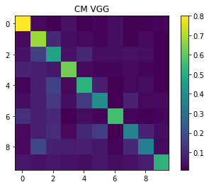

```python
plt.imshow(vgg)
plt.colorbar()
plt.title('CM VGG')
```

```
Text(0.5,1,'CM ResNet')
```

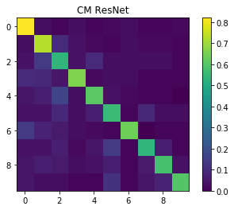

```python
plt.imshow(resnet)
plt.colorbar()
plt.title('CM ResNet')
```

# Actividad 3

El resultado elegido de la red LSTM es el siguiente

```
Total Characters: 311144
Total Vocab: 40
Total Patterns: 311044
Seed:
" e habia dado.

  todo lo cual hecho y cumplido, sin despedirse panza de sus
hijos y mujer, ni don qu "

ijote de la mancha, con la caballeria andante, que esta a eacer una senua para que el pera de la dara la cabazl, y las auena suerte de asuella andar d

Done.
```

El texto entre comillas corresponde a la semilla entregada al sistema, es decir la red intentará continuarlo. Se observa que la combinación **qu** es correctamente como **quijote**, aunque existen varias palabras que no tienen sentido, y sólo se aproximan a una estructura de texto donde existen conectores y sustantivos debidamente distribuidos.

# Actividad 4

```
# define the LSTM model
model = Sequential()
model.add(LSTM(256, return_sequences=True, input_shape=(X.shape[1], X.shape[2]) ))
model.add(LSTM(256))
model.add(Dropout(0.2))
model.add(Dense(y.shape[1], activation='softmax'))
model.summary()

_________________________________________________________________
Layer (type)                 Output Shape              Param #
=================================================================
lstm_1 (LSTM)                (None, 100, 256)          264192
_________________________________________________________________
lstm_2 (LSTM)                (None, 256)               525312
_________________________________________________________________
dropout_1 (Dropout)          (None, 256)               0
_________________________________________________________________
dense_1 (Dense)              (None, 40)                10280
=================================================================
Total params: 799,784
Trainable params: 799,784
Non-trainable params: 0
_________________________________________________________________
```

En este caso la dimensionalidad de la entrada es de 1 debido a que se ingresa un caracter a la vez, más un bias adicional. Para la segunda capa los datos de entrada son de dimensionalidad $256+1$, también debido al bias.

Siguiendo [esta lógica](http://arunmallya.github.io/writeups/nn/lstm/index.html#/2) se tiene que la cantidad total de parámetros viene dada por

$$ 4d(n+d) $$

Donde $n$ es la dimensión de la entrada $x$ y $d$ es la cantidad unidades de memoria, de aquí entonces para la primera capa

$$ 4\times((1+1)\times256+256^{2})= 264192$$

Y para la segunda

$$ 4\times((256+1)\times256+256^{2})= 525312$$

Finalmente para la capa densa, la cantidad de parámetros es el resultado de conectar las 256+1 salidas con todas las 40 neuronas

$$ (256+1)\times40=10280 $$

# Actividad 5

Ejecutando el código con dos redes LSTM, da el siguiente resultado

```
(diplomado) grupo12_ml@kraken:~$  python /opt/bigdata/lab2_ml/generate2.py
Using TensorFlow backend.
Total Characters: 311144
Total Vocab: 40
Total Patterns: 311044
Seed:
"  porque en efecto eran hombres como
nosotros, has de entender tambien que, andando lo mas del tiempo "

 que en el corral de la mancha, que es mandado esta a su amo, y a decir esto, que estaba estar a la mano y la mano y la vida de la mancha, que es mand
Done.
```

El resultado de ambas LSTM en serie pareciera añadir coherencia al texto. Considerando que la salida de la primera red LSTM se ingresa a la segunda, pareciera conducir a la redundancia de aquellas palabras que ingresaron a la primera.